# Project: Investigate "Medical Appointment No Shows" Dataset

## Introduction

In this project, I will be investigating through more than 100K appoinments recoreds to get better understaning of why 30% of patients miss thier medical appointments in Brazil. The appointment records include some characterisitcs about the appointmet, some about the patients, and about the medical center. Below, I will put some information about each of characterisitcs.

| **Original Characteristic** | **Renamed Characteristics** | **Used Type** | **Description** |
| --- | --- | --- | --- |
| PatientId | patient_id | int64 | Identification of a patient |
| AppointmentID | appointment_id | int64 | Identification of each appointment |
| Gender | gender | object | Male or Female. |
| DataMarcacaoConsulta | scheduled_day | datetime64[ns, UTC] | The day of the actual appointment, when they have to visit the doctor. |
| DataAgendamento | appointment_day | datetime64[ns, UTC] | The day someone called or registered the appointment, this is before appointment of course. |
| Age | age | int64 | Age of the patient |
| Neighbourhood | hospital_district | object | Where the appointment takes place. |
| Scholarship | gets_aid | bool | Whether the patient gets financial aid from the government or not. |
| Hipertension | hypertension | bool | Whether the patient diagnosed with Hypertension or not. |
| Diabetes | diabetes | bool | Whether the patient diagnosed with Diabetes or not. |
| Alcoholism | alcoholism | bool | Whether the patient diagnosed with alcohol use disorder or not. |
| Handcap | handicapped | bool | Whether the patient is handicapped or not. |
| SMS_received | sms_received | bool | Whether 1 or more messages sent to the patient or not |
| No-show | no_show | object | Whether the patient showed up for the appointment or not. |
|  | age_to | int64 | The open end of each age interval [0 -15, 15 - 30, 30 - 45, 45 - 60, 60 - 75, 75 - 90, 90 - 105, 105 - 120] |

During the investigation, I try to answer the following questions to get better under standing and be able to share a conclusion of why 30% of patiens miss their appointment:

1- How many appointments were missed? And what was the pecentage of the missed appointments?

2- Which age group has the most and least appointment miss interms of numbers, and percentages?

3- How many appointments were missed given the patient receives the govermental financial aid? and

4- What is their percentage compared to the whole sample? and to the people missed their appointments?

other questions could be answered as well on later time:

1- what about other given illness? are their ratios more or less than who get the financial aid?

2- Do people with more than 1 illness tend to miss their appoint more often?

3- Which location has the most and least missings in terms of numbers and percentages?

4- Are those locations visted by patients receives financial aid? (locations with high poverty)

```python
#import Packages
import pandas as pd
import numpy as np
import matplotlib.pyplot as plt
from datetime import datetime
import seaborn as sns

%matplotlib inline
```

```python
#time calculator whenever needed
def delta(start, end):
    return (end - start).total_seconds()
```

## Data Wrangling

- Loading the data, and displaying the first row to verify the loading step.

```python
#load the data, and display the first rows
df = pd.read_csv('https://d17h27t6h515a5.cloudfront.net/topher/2017/October/59dd2e9a_noshowappointments-kagglev2-may-2016/noshowappointments-kagglev2-may-2016.csv')

df.head()
```

|  | PatientId | AppointmentID | Gender | ScheduledDay | AppointmentDay | Age | Neighbourhood | Scholarship | Hipertension | Diabetes | Alcoholism | Handcap | SMS_received | No-show |
| --- | --- | --- | --- | --- | --- | --- | --- | --- | --- | --- | --- | --- | --- | --- |
| 0 | 2.987250e+13 | 5642903 | F | 2016-04-29T18:38:08Z | 2016-04-29T00:00:00Z | 62 | JARDIM DA PENHA | 0 | 1 | 0 | 0 | 0 | 0 | No |
| 1 | 5.589978e+14 | 5642503 | M | 2016-04-29T16:08:27Z | 2016-04-29T00:00:00Z | 56 | JARDIM DA PENHA | 0 | 0 | 0 | 0 | 0 | 0 | No |
| 2 | 4.262962e+12 | 5642549 | F | 2016-04-29T16:19:04Z | 2016-04-29T00:00:00Z | 62 | MATA DA PRAIA | 0 | 0 | 0 | 0 | 0 | 0 | No |
| 3 | 8.679512e+11 | 5642828 | F | 2016-04-29T17:29:31Z | 2016-04-29T00:00:00Z | 8 | PONTAL DE CAMBURI | 0 | 0 | 0 | 0 | 0 | 0 | No |
| 4 | 8.841186e+12 | 5642494 | F | 2016-04-29T16:07:23Z | 2016-04-29T00:00:00Z | 56 | JARDIM DA PENHA | 0 | 1 | 1 | 0 | 0 | 0 | No |

- The column names need to be renamed for better understanding and easier to work with.

```python
#Rename cloumn titles for better understanding, and display first line to verify
df_renamed = df.rename(columns={'PatientId':'patient_id',
                               'AppointmentID':'appointment_id',
                               'Gender':'gender',
                               'ScheduledDay':'scheduled_day',
                               'AppointmentDay':'appointment_day',
                               'Age':'age',
                               'Neighbourhood':'hospital_district',
                               'Scholarship':'gets_aid',
                               'Hipertension':'hypertension',
                               'Diabetes':'diabetes',
                               'Alcoholism':'alcoholism',
                               'Handcap':'handicapped',
                               'SMS_received':'sms_received',
                               'No-show':'no_show'})
df_renamed.head(0)
```

|  | patient_id | appointment_id | gender | scheduled_day | appointment_day | age | hospital_district | gets_aid | hypertension | diabetes | alcoholism | handicapped | sms_received | no_show |
| --- | --- | --- | --- | --- | --- | --- | --- | --- | --- | --- | --- | --- | --- | --- |

- After enhancing the columns names, now it is time to get general information about the data. Also, prepare the data for further exploring.

```python
#Get general information about the data
df_renamed.info()
```

```
<class 'pandas.core.frame.DataFrame'>
RangeIndex: 110527 entries, 0 to 110526
Data columns (total 14 columns):
patient_id           110527 non-null float64
appointment_id       110527 non-null int64
gender               110527 non-null object
scheduled_day        110527 non-null object
appointment_day      110527 non-null object
age                  110527 non-null int64
hospital_district    110527 non-null object
gets_aid             110527 non-null int64
hypertension         110527 non-null int64
diabetes             110527 non-null int64
alcoholism           110527 non-null int64
handicapped          110527 non-null int64
sms_received         110527 non-null int64
no_show              110527 non-null object
dtypes: float64(1), int64(8), object(5)
memory usage: 11.8+ MB
```

- The data shows that there are 110,527 rows/records in 14 columns, and non of them is null. However,a varification step will be done as well as checking the data for possible duplicated rows. The data also shows different types of data which most of them need to be modified to appropriate ones.

```python
#Ensuring the data has no null fields.
df_renamed.dropna().isnull().sum()
```

```
patient_id           0
appointment_id       0
gender               0
scheduled_day        0
appointment_day      0
age                  0
hospital_district    0
gets_aid             0
hypertension         0
diabetes             0
alcoholism           0
handicapped          0
sms_received         0
no_show              0
dtype: int64
```

```python
#Checking for possible duplicated rows.
df_renamed.duplicated().sum()
```

```
0
```

```python
#Modify the patient_id type to integer.
df_renamed['patient_id']= df_renamed['patient_id'].astype('int64')
```

```python
#Modify the date com=lumns types to the Date-Time one.
df_renamed['scheduled_day'] =  pd.to_datetime(df_renamed['scheduled_day'])
df_renamed['appointment_day'] =  pd.to_datetime(df_renamed['appointment_day'])
```

```python
#Checking the data in the binary fields
df_renamed.gets_aid.unique(), df_renamed.hypertension.unique(), df_renamed.diabetes.unique(), df_renamed.alcoholism.unique(), df_renamed.handicapped.unique(), df_renamed.sms_received.unique(), df_renamed.no_show.unique()
```

```
(array([0, 1]),
 array([1, 0]),
 array([0, 1]),
 array([0, 1]),
 array([0, 1, 2, 3, 4]),
 array([0, 1]),
 array(['No', 'Yes'], dtype=object))
```

- The Handicapped values should only have 0 or 1 as per given data information. Counting the number of records with non-sense values to either drop them or take a further invetigation.

```python
#Checking the number of rows for Handicapped with data greater than 1.
df_renamed.query('handicapped > 1').count()['handicapped']
```

```
199
```

- As the number of rows is 199 only, this data with value of greater than one will be dropped without any further investigation.

```python
#Drop the rows where the handicapped(hc) values are greater than one, before modifying the type for it and the rest as boolean.
df_renamed.drop(df_renamed.index[df_renamed['handicapped'] > 1], inplace=True)
df_renamed.query('handicapped > 1').count(), df_renamed.gets_aid.unique(), df_renamed.hypertension.unique(), df_renamed.diabetes.unique(), df_renamed.alcoholism.unique(), df_renamed.handicapped.unique(), df_renamed.sms_received.unique(), df_renamed.no_show.unique()
```

```
(patient_id           0
 appointment_id       0
 gender               0
 scheduled_day        0
 appointment_day      0
 age                  0
 hospital_district    0
 gets_aid             0
 hypertension         0
 diabetes             0
 alcoholism           0
 handicapped          0
 sms_received         0
 no_show              0
 dtype: int64,
 array([0, 1]),
 array([1, 0]),
 array([0, 1]),
 array([0, 1]),
 array([0, 1]),
 array([0, 1]),
 array(['No', 'Yes'], dtype=object))
```

- Now, converting types of the following columns to boolean:
  - gets_aid,
  - hypertension,
  - diabetes,
  - alcoholism,
  - handicapped, and
  - sms_received.

```python
#Modyfing types of the columns: gets_aid, hypertension, diabetes, alcoholism, handicapped, sms_received, and no_show to boolean
bool_columns = ['gets_aid', 'hypertension', 'diabetes', 'alcoholism', 'handicapped', 'sms_received']

for c in bool_columns:
    df_renamed[c] = df_renamed[c].astype('bool')

df_renamed.info()
```

```
<class 'pandas.core.frame.DataFrame'>
Int64Index: 110328 entries, 0 to 110526
Data columns (total 14 columns):
patient_id           110328 non-null int64
appointment_id       110328 non-null int64
gender               110328 non-null object
scheduled_day        110328 non-null datetime64[ns]
appointment_day      110328 non-null datetime64[ns]
age                  110328 non-null int64
hospital_district    110328 non-null object
gets_aid             110328 non-null bool
hypertension         110328 non-null bool
diabetes             110328 non-null bool
alcoholism           110328 non-null bool
handicapped          110328 non-null bool
sms_received         110328 non-null bool
no_show              110328 non-null object
dtypes: bool(6), datetime64[ns](2), int64(3), object(3)
memory usage: 8.2+ MB
```

- Now, general checking of the records for further investigation, and better understanding.

```python
df_renamed.describe()
```

|  | patient_id | appointment_id | age |
| --- | --- | --- | --- |
| count | 1.103280e+05 | 1.103280e+05 | 110328.000000 |
| mean | 1.475273e+14 | 5.675299e+06 | 37.070408 |
| std | 2.561394e+14 | 7.129914e+04 | 23.098231 |
| min | 3.921700e+04 | 5.030230e+06 | -1.000000 |
| 25% | 4.174654e+12 | 5.640278e+06 | 18.000000 |
| 50% | 3.175389e+13 | 5.680568e+06 | 37.000000 |
| 75% | 9.439381e+13 | 5.725510e+06 | 55.000000 |
| max | 9.999816e+14 | 5.790484e+06 | 115.000000 |

- The age shows a negative value. Record(s) shall be checked and dropped if needed.

```python
#Check the negative data, in order to drop it, or have further investigation.
df_renamed[df_renamed['age'] < 0]
```

|  | patient_id | appointment_id | gender | scheduled_day | appointment_day | age | hospital_district | gets_aid | hypertension | diabetes | alcoholism | handicapped | sms_received | no_show |
| --- | --- | --- | --- | --- | --- | --- | --- | --- | --- | --- | --- | --- | --- | --- |
| 99832 | 465943158731293 | 5775010 | F | 2016-06-06 08:58:13 | 2016-06-06 | -1 | ROMÃO | False | False | False | False | False | False | No |

```python
#Drop the whole row of the negative age value.  Then check again to confirm dropping.
df_cleaning_age = df_renamed.drop(df_renamed.index[df_renamed['age'] < 0])
df_cleaning_age[df_cleaning_age['age'] < 0]
```

|  | patient_id | appointment_id | gender | scheduled_day | appointment_day | age | hospital_district | gets_aid | hypertension | diabetes | alcoholism | handicapped | sms_received | no_show |
| --- | --- | --- | --- | --- | --- | --- | --- | --- | --- | --- | --- | --- | --- | --- |

- Now, new column shall be created to group the data by age. The ages will be devided equaliy every 15 years. The assumption is that every 15 year the dependency and maturity. For example, people less than 15 year of age would be depending on their parents to schedule and attend the appointment.

```python
# creating age intervals every 15 years, from 0:15:30:...etc, and check result.
age_to = []
for value in df_cleaning_age['age']:
    if value < 15:
        age_to.append(15)
    elif value < 30:
        age_to.append(30)
    elif value < 45:
        age_to.append(45)
    elif value < 60:
        age_to.append(60)
    elif value < 75:
        age_to.append(75)
    elif value < 90:
        age_to.append(90)
    elif value < 105:
        age_to.append(105)
    elif value < 120:
        age_to.append(120)


df_cleaning_age['age_to'] = age_to
clean_df = df_cleaning_age
clean_df.head(20)
```

|  | patient_id | appointment_id | gender | scheduled_day | appointment_day | age | hospital_district | gets_aid | hypertension | diabetes | alcoholism | handicapped | sms_received | no_show | age_to |
| --- | --- | --- | --- | --- | --- | --- | --- | --- | --- | --- | --- | --- | --- | --- | --- |
| 0 | 29872499824296 | 5642903 | F | 2016-04-29 18:38:08 | 2016-04-29 | 62 | JARDIM DA PENHA | False | True | False | False | False | False | No | 75 |
| 1 | 558997776694438 | 5642503 | M | 2016-04-29 16:08:27 | 2016-04-29 | 56 | JARDIM DA PENHA | False | False | False | False | False | False | No | 60 |
| 2 | 4262962299951 | 5642549 | F | 2016-04-29 16:19:04 | 2016-04-29 | 62 | MATA DA PRAIA | False | False | False | False | False | False | No | 75 |
| 3 | 867951213174 | 5642828 | F | 2016-04-29 17:29:31 | 2016-04-29 | 8 | PONTAL DE CAMBURI | False | False | False | False | False | False | No | 15 |
| 4 | 8841186448183 | 5642494 | F | 2016-04-29 16:07:23 | 2016-04-29 | 56 | JARDIM DA PENHA | False | True | True | False | False | False | No | 60 |
| 5 | 95985133231274 | 5626772 | F | 2016-04-27 08:36:51 | 2016-04-29 | 76 | REPÚBLICA | False | True | False | False | False | False | No | 90 |
| 6 | 733688164476661 | 5630279 | F | 2016-04-27 15:05:12 | 2016-04-29 | 23 | GOIABEIRAS | False | False | False | False | False | False | Yes | 30 |
| 7 | 3449833394123 | 5630575 | F | 2016-04-27 15:39:58 | 2016-04-29 | 39 | GOIABEIRAS | False | False | False | False | False | False | Yes | 45 |
| 8 | 56394729949972 | 5638447 | F | 2016-04-29 08:02:16 | 2016-04-29 | 21 | ANDORINHAS | False | False | False | False | False | False | No | 30 |
| 9 | 78124564369297 | 5629123 | F | 2016-04-27 12:48:25 | 2016-04-29 | 19 | CONQUISTA | False | False | False | False | False | False | No | 30 |
| 10 | 734536231958495 | 5630213 | F | 2016-04-27 14:58:11 | 2016-04-29 | 30 | NOVA PALESTINA | False | False | False | False | False | False | No | 45 |
| 11 | 7542951368435 | 5620163 | M | 2016-04-26 08:44:12 | 2016-04-29 | 29 | NOVA PALESTINA | False | False | False | False | False | True | Yes | 30 |
| 12 | 566654781423437 | 5634718 | F | 2016-04-28 11:33:51 | 2016-04-29 | 22 | NOVA PALESTINA | True | False | False | False | False | False | No | 30 |
| 13 | 911394617215919 | 5636249 | M | 2016-04-28 14:52:07 | 2016-04-29 | 28 | NOVA PALESTINA | False | False | False | False | False | False | No | 30 |
| 14 | 99884723334928 | 5633951 | F | 2016-04-28 10:06:24 | 2016-04-29 | 54 | NOVA PALESTINA | False | False | False | False | False | False | No | 60 |
| 15 | 99948393975 | 5620206 | F | 2016-04-26 08:47:27 | 2016-04-29 | 15 | NOVA PALESTINA | False | False | False | False | False | True | No | 30 |
| 16 | 84574392942817 | 5633121 | M | 2016-04-28 08:51:47 | 2016-04-29 | 50 | NOVA PALESTINA | False | False | False | False | False | False | No | 60 |
| 17 | 14794966191172 | 5633460 | F | 2016-04-28 09:28:57 | 2016-04-29 | 40 | CONQUISTA | True | False | False | False | False | False | Yes | 45 |
| 18 | 17135378245248 | 5621836 | F | 2016-04-26 10:54:18 | 2016-04-29 | 30 | NOVA PALESTINA | True | False | False | False | False | True | No | 45 |
| 19 | 7223289184215 | 5640433 | F | 2016-04-29 10:43:14 | 2016-04-29 | 46 | DA PENHA | False | False | False | False | False | False | No | 60 |

```python
clean_df.shape
```

```
(110327, 15)
```

After cleaning the data, now number of records are 110,327 filling each of the 15 columns.

## Exploratory Data Analysis

### How many appointments were missed? And what was the pecentage of the missed appointments?

```python
total_count= clean_df.no_show.count()
no_show_total = clean_df.no_show.str.count('Yes').sum()
no_show_total_share = no_show_total/total_count*100
attended_share = 100 - no_show_total_share
print(no_show_total, no_show_total_share, attended_share)
```

```
22278 20.1926998831 79.8073001169
```

```
Text(0.5,1,'No Show Shares')
```

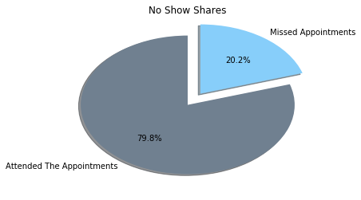

```python
#plt.pie(no_show)
plt.pie([attended_share, no_show_total_share ], labels=['Attended The Appointments', 'Missed Appointments'],
        shadow=True, explode=(0,0.2), startangle=90, autopct='%1.1f%%', colors=['slategrey','lightskyblue'])
plt.title('No Show Shares')
```

The chart shows that about 20% of the appointments were missed. I will try to confirm whether 30% of patients miss their appointment. So, I need to create a new data frame with unique patient id to get more understanding.

```python
#Create a dafa frame for unique patients
unique_list = list(clean_df.patient_id.unique())
unique_df = pd.DataFrame(unique_list, columns =['unique_patient_id'])
unique_df
```

|  | unique_patient_id |
| --- | --- |
| 0 | 29872499824296 |
| 1 | 558997776694438 |
| 2 | 4262962299951 |
| 3 | 867951213174 |
| 4 | 8841186448183 |
| 5 | 95985133231274 |
| 6 | 733688164476661 |
| 7 | 3449833394123 |
| 8 | 56394729949972 |
| 9 | 78124564369297 |
| 10 | 734536231958495 |
| 11 | 7542951368435 |
| 12 | 566654781423437 |
| 13 | 911394617215919 |
| 14 | 99884723334928 |
| 15 | 99948393975 |
| 16 | 84574392942817 |
| 17 | 14794966191172 |
| 18 | 17135378245248 |
| 19 | 7223289184215 |
| 20 | 622257462899397 |
| 21 | 12154843752835 |
| 22 | 863229818887631 |
| 23 | 213753979425692 |
| 24 | 8734857996885 |
| 25 | 5819369978796 |
| 26 | 25787851512 |
| 27 | 5926171692527 |
| 28 | 1225776163665 |
| 29 | 342815551642 |
| ... | ... |
| 62160 | 9167383147643 |
| 62161 | 166417977651999 |
| 62162 | 1269372271177 |
| 62163 | 5966967288936 |
| 62164 | 6238227932876 |
| 62165 | 62721147981868 |
| 62166 | 43247548219715 |
| 62167 | 4994741664898 |
| 62168 | 22853763289851 |
| 62169 | 3346244796486 |
| 62170 | 984889536466572 |
| 62171 | 8567868434363 |
| 62172 | 822295998972 |
| 62173 | 322747477995 |
| 62174 | 755529974129 |
| 62175 | 9278752487294 |
| 62176 | 4455243979994 |
| 62177 | 594422525164283 |
| 62178 | 787436994766271 |
| 62179 | 325262361689699 |
| 62180 | 756562242135 |
| 62181 | 171213473862 |
| 62182 | 7499488949126 |
| 62183 | 454425189389 |
| 62184 | 823599626588 |
| 62185 | 98762456447375 |
| 62186 | 86747784995281 |
| 62187 | 72633149253362 |
| 62188 | 996997666245785 |
| 62189 | 15576631729893 |

62190 rows × 1 columns

```python
# The code below have been done once, and saved to a DataFrame to save time for later use.

#unique_yes = []
#list_length = len(unique_list)

#for i in range(list_length):
#        unique_yes.append(sum(clean_df[clean_df['no_show'] == "Yes"]['patient_id'] == unique_list[i]))
```

```python
# The code below have been done once, and saved to a DataFrame to save time for later use.

#unique_yes
```

This method will take very long time, more than 779 seconds to iterate over the unique_list. I will try another method, or I will do it once and then save to new DataFrame.

```python
# The code below have been done once, and saved to a DataFrame to save time for later use.

#unique_no = []
#list_length = len(unique_list)

#for i in range(list_length):
#        unique_no.append(sum(clean_df[clean_df['no_show'] == "No"]['patient_id'] == unique_list[i]))
```

```python
# The code below have been done once, and saved to a DataFrame to save time for later use.

#unique_no
```

```python
# The code below have been done once, and saved to a DataFrame to save time for later use.

#d = {'unique_patient_id':unique_list,'no_show':unique_yes, 'show':unique_no}

#unique_df2 = pd.DataFrame(d)
```

```python
# The code below have been done once, and saved to a DataFrame to save time for later use.

# saving the dataframe
#unique_df2.to_csv(r'C:\Users\ksasa\anaconda3\envs\P2\uniue_df2.csv', index=False)
#unique_df2.head()
```

```python
unique_df2 = pd.read_csv(r'C:\Users\ksasa\anaconda3\envs\P2\uniue_df2.csv')
unique_df2.head()
```

|  | unique_patient_id | no_show | show |
| --- | --- | --- | --- |
| 0 | 29872499824296 | 0 | 2 |
| 1 | 558997776694438 | 0 | 2 |
| 2 | 4262962299951 | 0 | 2 |
| 3 | 867951213174 | 1 | 1 |
| 4 | 8841186448183 | 0 | 1 |

```python
#getting the sums for no_show and show
unique_df2['calculated_scheduled']=unique_df2.no_show + unique_df2.show
unique_df2.head()
```

|  | unique_patient_id | no_show | show | calculated_scheduled |
| --- | --- | --- | --- | --- |
| 0 | 29872499824296 | 0 | 2 | 2 |
| 1 | 558997776694438 | 0 | 2 | 2 |
| 2 | 4262962299951 | 0 | 2 | 2 |
| 3 | 867951213174 | 1 | 1 | 2 |
| 4 | 8841186448183 | 0 | 1 | 1 |

```python
unique_df2.info()
```

```
<class 'pandas.core.frame.DataFrame'>
RangeIndex: 62190 entries, 0 to 62189
Data columns (total 4 columns):
unique_patient_id       62190 non-null int64
no_show                 62190 non-null int64
show                    62190 non-null int64
calculated_scheduled    62190 non-null int64
dtypes: int64(4)
memory usage: 1.9 MB
```

```python
#calculating the percentages for no_show per patient
unique_df2['no_show_pcnt']=unique_df2.no_show / unique_df2.calculated_scheduled*100
unique_df2.head()
```

|  | unique_patient_id | no_show | show | calculated_scheduled | no_show_pcnt |
| --- | --- | --- | --- | --- | --- |
| 0 | 29872499824296 | 0 | 2 | 2 | 0.0 |
| 1 | 558997776694438 | 0 | 2 | 2 | 0.0 |
| 2 | 4262962299951 | 0 | 2 | 2 | 0.0 |
| 3 | 867951213174 | 1 | 1 | 2 | 50.0 |
| 4 | 8841186448183 | 0 | 1 | 1 | 0.0 |

```python
#The caculated scheduled appionments should equal the count of clean_df.scheduled_day, let's check
clean_df.scheduled_day.count() == unique_df2.calculated_scheduled.sum()
```

```
True
```

```python
# sorting unique_df2
unique_df2.sort_values(["no_show_pcnt","calculated_scheduled"], axis = 0, ascending = [False,False])
```

|  | unique_patient_id | no_show | show | calculated_scheduled | no_show_pcnt |
| --- | --- | --- | --- | --- | --- |
| 34850 | 1421986987763 | 18 | 0 | 18 | 100.0 |
| 34853 | 563513528548171 | 16 | 0 | 16 | 100.0 |
| 34847 | 581197334462339 | 14 | 0 | 14 | 100.0 |
| 34859 | 65751443779385 | 13 | 0 | 13 | 100.0 |
| 17970 | 93388598973955 | 10 | 0 | 10 | 100.0 |
| 34886 | 46836777451462 | 9 | 0 | 9 | 100.0 |
| 34908 | 216298164113 | 8 | 0 | 8 | 100.0 |
| 13496 | 28516799229 | 7 | 0 | 7 | 100.0 |
| 34926 | 34849787522388 | 7 | 0 | 7 | 100.0 |
| 1472 | 1144471549922 | 6 | 0 | 6 | 100.0 |
| 11428 | 97173476551 | 6 | 0 | 6 | 100.0 |
| 17972 | 68841236844344 | 6 | 0 | 6 | 100.0 |
| 30903 | 5443246792943 | 6 | 0 | 6 | 100.0 |
| 59575 | 679765568947665 | 6 | 0 | 6 | 100.0 |
| 12009 | 24169265844 | 5 | 0 | 5 | 100.0 |
| 14402 | 6489489444136 | 5 | 0 | 5 | 100.0 |
| 14769 | 8737798312456 | 5 | 0 | 5 | 100.0 |
| 18972 | 95541412376898 | 5 | 0 | 5 | 100.0 |
| 27863 | 56223961661455 | 5 | 0 | 5 | 100.0 |
| 30896 | 513852242416315 | 5 | 0 | 5 | 100.0 |
| 1863 | 245283137241886 | 4 | 0 | 4 | 100.0 |
| 2440 | 131487155245 | 4 | 0 | 4 | 100.0 |
| 3607 | 56692679146 | 4 | 0 | 4 | 100.0 |
| 6257 | 44572264533633 | 4 | 0 | 4 | 100.0 |
| 7145 | 24394785966683 | 4 | 0 | 4 | 100.0 |
| 7522 | 4841899892433 | 4 | 0 | 4 | 100.0 |
| 7817 | 17895957452917 | 4 | 0 | 4 | 100.0 |
| 10759 | 83592665524633 | 4 | 0 | 4 | 100.0 |
| 11306 | 25488622482828 | 4 | 0 | 4 | 100.0 |
| 19712 | 246558983545642 | 4 | 0 | 4 | 100.0 |
| ... | ... | ... | ... | ... | ... |
| 62142 | 21214558235863 | 0 | 1 | 1 | 0.0 |
| 62146 | 449338751519574 | 0 | 1 | 1 | 0.0 |
| 62149 | 98755486272818 | 0 | 1 | 1 | 0.0 |
| 62154 | 2423178274347 | 0 | 1 | 1 | 0.0 |
| 62157 | 799421915531 | 0 | 1 | 1 | 0.0 |
| 62159 | 4441557591775 | 0 | 1 | 1 | 0.0 |
| 62163 | 5966967288936 | 0 | 1 | 1 | 0.0 |
| 62164 | 6238227932876 | 0 | 1 | 1 | 0.0 |
| 62165 | 62721147981868 | 0 | 1 | 1 | 0.0 |
| 62166 | 43247548219715 | 0 | 1 | 1 | 0.0 |
| 62167 | 4994741664898 | 0 | 1 | 1 | 0.0 |
| 62168 | 22853763289851 | 0 | 1 | 1 | 0.0 |
| 62170 | 984889536466572 | 0 | 1 | 1 | 0.0 |
| 62171 | 8567868434363 | 0 | 1 | 1 | 0.0 |
| 62172 | 822295998972 | 0 | 1 | 1 | 0.0 |
| 62173 | 322747477995 | 0 | 1 | 1 | 0.0 |
| 62174 | 755529974129 | 0 | 1 | 1 | 0.0 |
| 62175 | 9278752487294 | 0 | 1 | 1 | 0.0 |
| 62178 | 787436994766271 | 0 | 1 | 1 | 0.0 |
| 62179 | 325262361689699 | 0 | 1 | 1 | 0.0 |
| 62180 | 756562242135 | 0 | 1 | 1 | 0.0 |
| 62181 | 171213473862 | 0 | 1 | 1 | 0.0 |
| 62182 | 7499488949126 | 0 | 1 | 1 | 0.0 |
| 62183 | 454425189389 | 0 | 1 | 1 | 0.0 |
| 62184 | 823599626588 | 0 | 1 | 1 | 0.0 |
| 62185 | 98762456447375 | 0 | 1 | 1 | 0.0 |
| 62186 | 86747784995281 | 0 | 1 | 1 | 0.0 |
| 62187 | 72633149253362 | 0 | 1 | 1 | 0.0 |
| 62188 | 996997666245785 | 0 | 1 | 1 | 0.0 |
| 62189 | 15576631729893 | 0 | 1 | 1 | 0.0 |

62190 rows × 5 columns

```python
# The code below have been done once, and saved to a DataFrame to save time for later use.

#create list for age_to to be added to unique_df3
#age_to_list= []
#for i in range(list_length):
#    age_to_list.append(clean_df['age_to'].loc[clean_df['patient_id'] == unique_df2['unique_patient_id'][i]].max())

#age_to_list
```

```python
# The code below have been done once, and saved to a DataFrame to save time for later use.

#unique_df3 = unique_df2
```

```python
# The code below have been done once, and saved to a DataFrame to save time for later use.

#unique_df3['age_to'] = age_to_list

# saving the dataframe
#unique_df3.to_csv(r'C:\Users\ksasa\anaconda3\envs\P2\uniue_df3.csv', index=False)
#unique_df3.head()
```

```python
unique_df3 = pd.read_csv(r'C:\Users\ksasa\anaconda3\envs\P2\uniue_df3.csv')
unique_df3['no_show_pcnt']=unique_df3.no_show / unique_df3.calculated_scheduled*100
unique_df3.head()
```

|  | unique_patient_id | no_show | show | calculated_scheduled | no_show_% | age_to | no_show_pcnt |
| --- | --- | --- | --- | --- | --- | --- | --- |
| 0 | 29872499824296 | 0 | 2 | 2 | 0.0 | 75 | 0.0 |
| 1 | 558997776694438 | 0 | 2 | 2 | 0.0 | 60 | 0.0 |
| 2 | 4262962299951 | 0 | 2 | 2 | 0.0 | 75 | 0.0 |
| 3 | 867951213174 | 1 | 1 | 2 | 50.0 | 15 | 50.0 |
| 4 | 8841186448183 | 0 | 1 | 1 | 0.0 | 60 | 0.0 |

```python
unique_df3.drop(unique_df3.columns[4], axis=1, inplace=True)
unique_df3.head()
```

|  | unique_patient_id | no_show | show | calculated_scheduled | age_to | no_show_pcnt |
| --- | --- | --- | --- | --- | --- | --- |
| 0 | 29872499824296 | 0 | 2 | 2 | 75 | 0.0 |
| 1 | 558997776694438 | 0 | 2 | 2 | 60 | 0.0 |
| 2 | 4262962299951 | 0 | 2 | 2 | 75 | 0.0 |
| 3 | 867951213174 | 1 | 1 | 2 | 15 | 50.0 |
| 4 | 8841186448183 | 0 | 1 | 1 | 60 | 0.0 |

```python
# sorting unique_df3
unique_df3.sort_values(["no_show_pcnt","calculated_scheduled"], axis = 0, ascending = [False,False]).head(10)
```

|  | unique_patient_id | no_show | show | calculated_scheduled | age_to | no_show_pcnt |
| --- | --- | --- | --- | --- | --- | --- |
| 34850 | 1421986987763 | 18 | 0 | 18 | 15 | 100.0 |
| 34853 | 563513528548171 | 16 | 0 | 16 | 15 | 100.0 |
| 34847 | 581197334462339 | 14 | 0 | 14 | 15 | 100.0 |
| 34859 | 65751443779385 | 13 | 0 | 13 | 15 | 100.0 |
| 17970 | 93388598973955 | 10 | 0 | 10 | 75 | 100.0 |
| 34886 | 46836777451462 | 9 | 0 | 9 | 30 | 100.0 |
| 34908 | 216298164113 | 8 | 0 | 8 | 30 | 100.0 |
| 13496 | 28516799229 | 7 | 0 | 7 | 30 | 100.0 |
| 34926 | 34849787522388 | 7 | 0 | 7 | 15 | 100.0 |
| 1472 | 1144471549922 | 6 | 0 | 6 | 30 | 100.0 |

```python
#Calculate the number and percentage of patients whom at least missed one apoointment.
patients_miss_appt = unique_df3.query('no_show > 0')
patients_miss_appt_count = patients_miss_appt.count()['age_to']
total_unique_count = unique_df3.count()['age_to']
patient_miss_appt_pcnt = patients_miss_appt.count()['age_to']/unique_df3.count()['age_to']*100
patient_attend_appt_pcnt = 100-patient_miss_appt_pcnt
patients_miss_appt_count, total_unique_count, patient_miss_appt_pcnt,patient_attend_appt_pcnt
```

```
(17632, 62190, 28.351825052259205, 71.648174947740799)
```

**17,632** patients with percentage about **28%** of the total pateints missed at least one appointment *as shown below*.

```
Text(0.5,1,'Patients Attendance Shares')
```

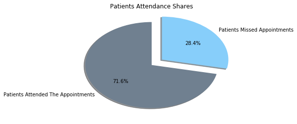

```python
#plt.pie(patients no_show shares)
plt.pie([patient_attend_appt_pcnt, patient_miss_appt_pcnt], labels=['Patients Attended The Appointments', 'Patients Missed Appointments'],
        shadow=True, explode=(0,0.2), startangle=90, autopct='%1.1f%%', colors=['slategrey','lightskyblue'])
plt.title('Patients Attendance Shares')
```

```python
patient_never_show = unique_df3.query('no_show_pcnt == 100')
patient_never_show_count = patient_never_show.count()['no_show']
patient_never_show_pcnt_of_missed = patient_never_show_count/patients_miss_appt_count*100
rest_patient_missed_pcnt = 100 - patient_never_show_pcnt_of_missed
patient_never_show_pcnt_of_total = patient_never_show_count/total_unique_count*100
rest_patient_total_pcnt = 100 - patient_never_show_pcnt_of_total
patient_never_show_count, patients_miss_appt_count, total_unique_count, patient_never_show_pcnt_of_missed, rest_patient_missed_pcnt, patient_never_show_pcnt_of_total, rest_patient_total_pcnt
```

```
(8133,
 17632,
 62190,
 46.1263611615245,
 53.8736388384755,
 13.077665219488663,
 86.922334780511335)
```

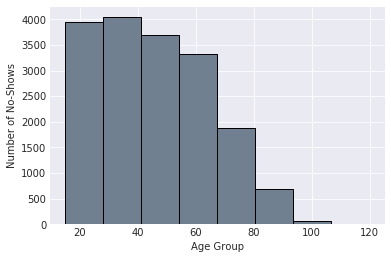

```python
intervals = ['0-15','15-30','30-45','45-60','60-75','75-90','90-105','105-120']
plt.hist( patients_miss_appt['age_to'], density=False, bins=8, facecolor='slategrey', edgecolor='black', label='intervals')
plt.ylabel('Number of No-Shows')
plt.xlabel('Age Group')
sns.set_style("darkgrid");
```

```
Text(0.5,1,'Patients Attendance Shares')
```

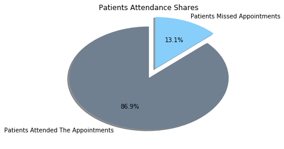

```python
#plt.pie(patients no_show shares)
plt.pie([rest_patient_total_pcnt, patient_never_show_pcnt_of_total], labels=['Patients Attended The Appointments', 'Patients Missed Appointments'],
        shadow=True, explode=(0,0.2), startangle=90, autopct='%1.1f%%', colors=['slategrey','lightskyblue'])
plt.title('Patients Attendance Shares')
```

```
Text(0.5,1,'Patients Attendance Shares')
```

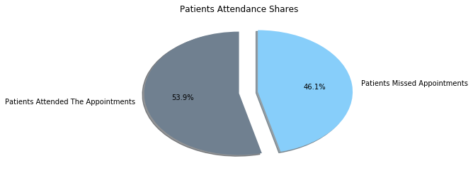

```python
#plt.pie(patients no_show shares)
plt.pie([rest_patient_missed_pcnt, patient_never_show_pcnt_of_missed], labels=['Patients Attended The Appointments', 'Patients Missed Appointments'],
        shadow=True, explode=(0,0.2), startangle=90, autopct='%1.1f%%', colors=['slategrey','lightskyblue'])
plt.title('Patients Attendance Shares')
```

```python
patient_never_show_byage = patient_never_show.groupby('age_to').count()['no_show']
patient_never_show_byage
```

```
age_to
15     1951
30     1909
45     1740
60     1439
75      751
90      312
105      31
Name: no_show, dtype: int64
```

```python
age_15_nevr_show = sum(patient_never_show.age_to == 15)
age_30_nevr_show = sum(patient_never_show.age_to == 30)
age_45_nevr_show = sum(patient_never_show.age_to == 45)
age_60_nevr_show = sum(patient_never_show.age_to == 60)
age_75_nevr_show = sum(patient_never_show.age_to == 75)
age_90_nevr_show = sum(patient_never_show.age_to == 90)
age_105_nevr_show = sum(patient_never_show.age_to == 105)
age_120_nevr_show = sum(patient_never_show.age_to == 120)
```

```python
age_15_never_pcnt = age_15_nevr_show/patient_never_show_count*100
age_30_never_pcnt = age_30_nevr_show/patient_never_show_count*100
age_45_never_pcnt = age_45_nevr_show/patient_never_show_count*100
age_60_never_pcnt = age_60_nevr_show/patient_never_show_count*100
age_75_never_pcnt = age_75_nevr_show/patient_never_show_count*100
age_90_never_pcnt = age_90_nevr_show/patient_never_show_count*100
age_105_never_pcnt = age_105_nevr_show/patient_never_show_count*100
age_120_never_pcnt = age_120_nevr_show/patient_never_show_count*100
age_15_never_pcnt,age_30_never_pcnt,age_45_never_pcnt,age_60_never_pcnt,age_75_never_pcnt,age_90_never_pcnt,age_105_never_pcnt,age_120_never_pcnt
```

```
(23.988688060986103,
 23.472273453830077,
 21.394319439321283,
 17.693348088036394,
 9.2339849993852212,
 3.8362227960162301,
 0.38116316242468951,
 0.0)
```

**8,133** patients scheduled appointment(s) and have never shown. That represent **13%** of the total number of patients, and **46%** of the patients who has missed at least one appoinement, and **24%** of them are kids under 15 years old.

### Which age group has the most and least appointment miss interms of numbers, and percentages?

```python
#creating data for no_show, and cheking their percentage of the whole sample.
no_show_df = clean_df.query('no_show == "Yes"')
no_show_df = no_show_df.drop(['no_show'], axis=1)
no_show_df['appointment_id'].count(), clean_df['appointment_id'].count(), no_show_df['appointment_id'].count()/clean_df['appointment_id'].count()*100
```

```
(22278, 110327, 20.192699883074859)
```

```python
#Getting the count and percentages of the missed appoinments grouped by age.
no_show_count =  no_show_df.groupby('age_to').count()['age']
no_show_percentage = no_show_df.groupby('age_to').count()['age']/clean_df.groupby('age_to')['no_show'].count()*100
no_show_count
```

```
age_to
15     4921
30     5191
45     4800
60     4143
75     2287
90      852
105      81
120       3
Name: age, dtype: int64
```

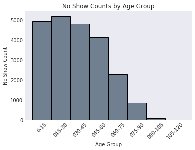

```python
#Bar chart of for no show counts by age group.  For some reason - maybe the version of matplotlib - I
#needed to walk around to get the same result as in my desktop Notebook version.
intervals = ['0-15','015-30','030-45','045-60','060-75','075-90','090-105','105-120']
plt.bar(intervals, no_show_count, width=1, facecolor='slategrey', edgecolor=['black','black','black','black','black','black','black','black'], align='center')
plt.xlabel('Age Group')
plt.ylabel('No Show Count')
plt.title('No Show Counts by Age Group')
plt.xticks(rotation = 45)
sns.set_style("darkgrid")
plt.show()
```

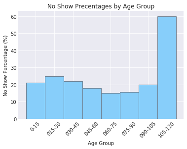

```python
#Bar chart of for no show percenages by age group.  For some reason - maybe the version of matplotlib - I
#needed to walk around to get the same result as in my desktop Notebook version.

intervals = ['0-15','015-30','030-45','045-60','060-75','075-90','090-105','105-120']
plt.bar(intervals, no_show_percentage, width=1, facecolor='lightskyblue', edgecolor=['slategrey','slategrey','slategrey','slategrey','slategrey','slategrey','slategrey','slategrey'], align='center')
plt.xlabel('Age Group')
plt.ylabel('No Show Percentage (%)')
plt.title('No Show Precentages by Age Group')
sns.set_style("darkgrid")
plt.xticks(rotation=45)
plt.show()
```

In terms of numbers, the group age from 15 to 30 are has the most appointment missed, and the number decreased afterwards. On the other hand, in terms of percentage, the centenarians have the most missed appointments with minimum appointments as numbers. The second to most appointments missed in terms of percentage are the people with age group from 15 to 30.

### How many appointments were missed given that the patient receives the govermental financial aid? and

### What is their percentage compared to the whole sample? and to the people missed their appointments?

```python
#poverty commitment check through the fainancial aids
no_show_with_aid_number = no_show_df['gets_aid'].value_counts()
no_show_with_aid_to_total = no_show_with_aid_number[True] / total_count*100
rest_no_show_with_aid_to_total = 100 - no_show_with_aid_to_total
no_show_with_aid_to_aided = no_show_df['gets_aid'].value_counts()/no_show_df['gets_aid'].count()*100
no_show_with_aid_number, no_show_with_aid_to_total, rest_no_show_with_aid_to_total, no_show_with_aid_to_aided
```

```
(False    19701
 True      2577
 Name: gets_aid, dtype: int64,
 2.3357836250419211,
 97.664216374958073,
 False    88.432534
 True     11.567466
 Name: gets_aid, dtype: float64)
```

```
2.3357836250419211
```

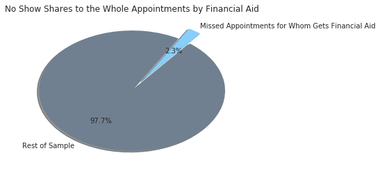

```python
#plt.pie(no_show_with_aid)
plt.pie([rest_no_show_with_aid_to_total, no_show_with_aid_to_total], labels=['Rest of Sample', 'Missed Appointments for Whom Gets Financial Aid'],
        shadow=True, explode=(0,0.2), startangle=60, autopct='%1.1f%%', colors=['slategrey','lightskyblue'])
plt.title('No Show Shares to the Whole Appointments by Financial Aid')
no_show_with_aid_to_total
```

```
Text(0.5,1,'No Show Shares by Financial Aid')
```

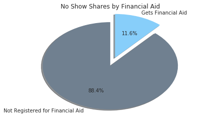

```python
#plt.pie(no_show_with_aid)
plt.pie(no_show_with_aid_to_aided, labels=['Not Registered for Financial Aid', 'Gets Financial Aid'],
        shadow=True, explode=(0,0.2), startangle=90, autopct='%1.1f%%', colors=['slategrey','lightskyblue'])
plt.title('No Show Shares by Financial Aid')
```

There are 2577 appointments missed given that the patients receives financial aid. They represent 2.3% from the who community, and 11.6% from the appointments missed

## Submitting your Project

```python
from subprocess import call
call(['python', '-m', 'nbconvert', 'Investigate_a_Dataset.ipynb'])
```